# Streaming Report

Matt Kruger

2025-06-19

# Introduction

In this report I will analyse what leads a movie to being popular on Netflix. Firstly I will create an OLS regression to determine the effects of several factors on a movies popularity. As an alternative form of analysis, I also create a ridgeline graph to investigate the distribution of popularity for different genres of movies.

# OLS Regression

In order to determine the factors which most affect a movies popularity, I will use OLS to regress a movie’s popularity on the country it was made in, the genre of the movie, the length of the movie, the imdb score of the movie(as this is more critics based as is likely to affect some viewers watching decisions), and the age restriction of the movie. I also include the year of release in order to control for time effects. However, as it is not a factor which affects popularity I leave it out of the regression table. For each of the categorical variables, I only conduct analysis on the top five most common observations, as those are likely to have the most significant effect on a movie’s popularity.

The table below presents the results of the regression

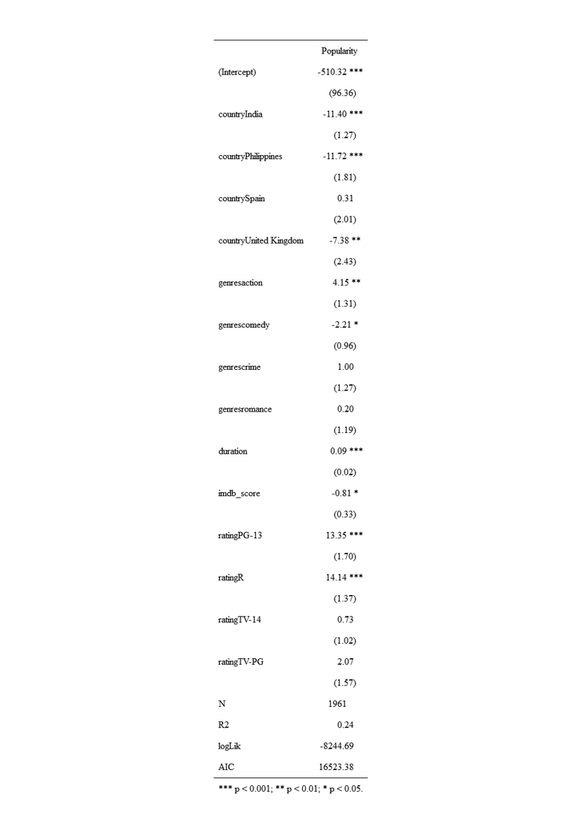

# Ridgeline

The ridgeline plot below illustrates the distribution of popularity scores for the top five most common movie genres on Netflix:

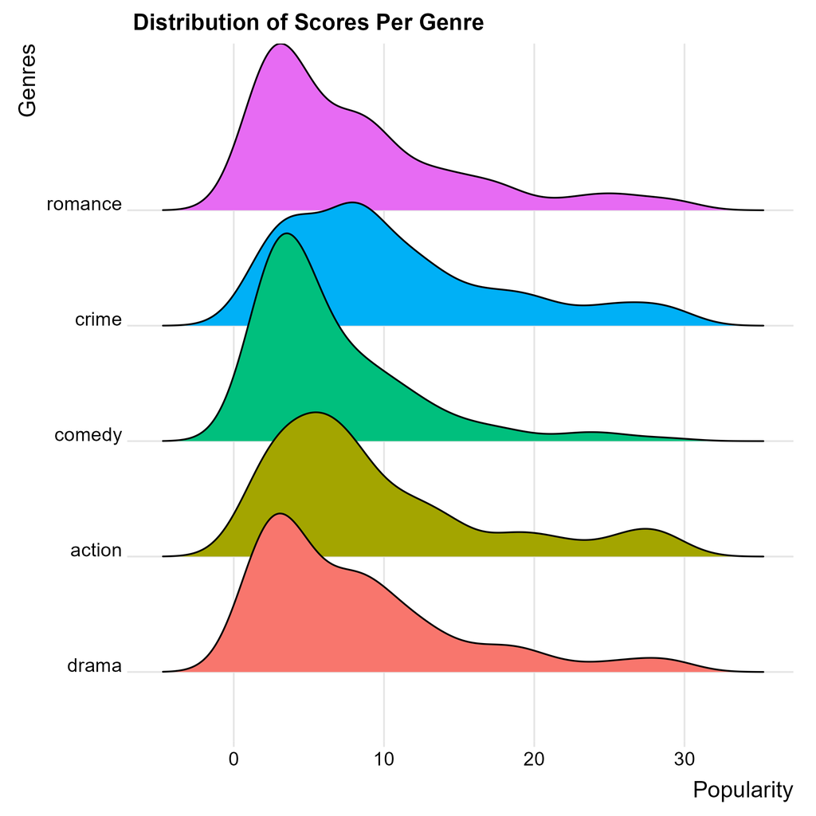

- Out of all the peaks of the distributions, the action and crime genres have the highest score. Crime movies in particular have a significant distribution which extends into the higher popularity scores.
- On the other hand, the drama genre’s distribution is particularly right-skewed.
- These results indicate that the company should focus investment into the crime and action genres.